# 文章标题

## 全周期分叉图

### 分叉图

绘制全周期分叉图的方法和第三次作业类似，这里不再进行说明，直接使用上次作业的函数（进行了一点优化）：

在 $r\in[0,2]$ 内均匀采样 $5 \times 10^3$ 个点，$x\in[-2,2]$ 内均匀随机选取 $20$ 个点，记录最后 $100$ 次的值（一个 $r$ 一共产生 $2\times 10^3$ 个点）.

这里我们忽略最终到达 $\pm \infty$ 的点（也就是我们只记录被吸引的点）

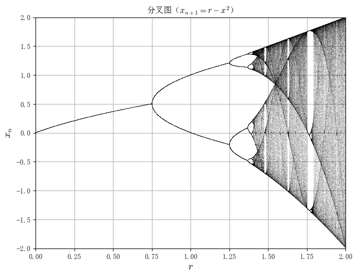

可以看见我们得到了一个类似前一次作业的 Logistic Map 的分叉图.

### 周期三

从全周期分叉图中我们可以看到，大概在 $r=1.75$ 附近出现周期三轨道. 这里我们针对这附近的范围进行放大：

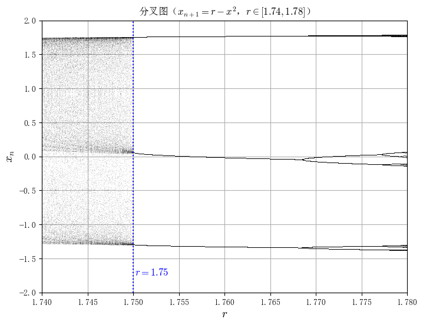

## 全参数范围的李雅普诺夫指数

### 计算思路

### 绘制

在 $r\in[0,2]$ 内均匀采样 $1 \times 10^3$ 个点，取 $x_0 = 0.1$，记录最后 $200$ 次的值来计算李雅普诺夫指数. 并绘制计算得到的李雅普诺夫指数和 $r$ 的关系：

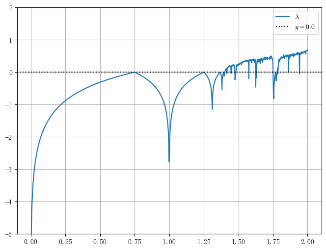

## 倍周期分叉点、$r_{\infty}$、费根鲍姆常数

### 通过费根鲍姆常数计算 $r_{\infty}$

## 为何其费根鲍姆常数与 Logistic Map 相同？

## 选做内容：

## 结论

## 参考资料

## 致谢

## 附一：问题

## 附二：学习心得